# beancount-jupyter notebook for exploaring a beancount file

## Notebook preparations

```
C:\_code\py\beancount-jupyter\.venv3.12\Scripts\python.exe
3.12.7 (tags/v3.12.7:0b05ead, Oct  1 2024, 03:06:41) [MSC v.1941 64 bit (AMD64)]
```

## Checks

### Beancount built in checks

## Misc

```
['USD']
```

## Chart of accounts

| account | currencies | open_date | close_date |
| --- | --- | --- | --- |
| Assets:US:BofA |  | 2015-01-01 |  |
| Assets:US:BofA:Checking | ['USD'] | 2015-01-01 |  |
| Assets:US:ETrade:Cash | ['USD'] | 2015-01-01 |  |
| Assets:US:ETrade:GLD | ['GLD'] | 2015-01-01 |  |
| Assets:US:ETrade:ITOT | ['ITOT'] | 2015-01-01 |  |
| Assets:US:ETrade:VEA | ['VEA'] | 2015-01-01 |  |
| Assets:US:ETrade:VHT | ['VHT'] | 2015-01-01 |  |
| Assets:US:Federal:PreTax401k | ['IRAUSD'] | 1980-05-12 |  |
| Assets:US:Hoogle:Vacation | ['VACHR'] | 2015-01-01 |  |
| Assets:US:Vanguard | ['USD'] | 2015-01-01 |  |
| Assets:US:Vanguard:Cash | ['USD'] | 2015-01-01 |  |
| Assets:US:Vanguard:RGAGX | ['RGAGX'] | 2015-01-01 |  |
| Assets:US:Vanguard:VBMPX | ['VBMPX'] | 2015-01-01 |  |
| Equity:Opening-Balances |  | 1980-05-12 |  |
| Expenses:Financial:Commissions |  | 1980-05-12 |  |
| Expenses:Financial:Fees |  | 1980-05-12 |  |
| Expenses:Food:Alcohol |  | 1980-05-12 |  |
| Expenses:Food:Coffee |  | 1980-05-12 |  |
| Expenses:Food:Groceries |  | 1980-05-12 |  |
| Expenses:Food:Restaurant |  | 1980-05-12 |  |
| Expenses:Health:Dental:Insurance |  | 2015-01-01 |  |
| Expenses:Health:Life:GroupTermLife |  | 2015-01-01 |  |
| Expenses:Health:Medical:Insurance |  | 2015-01-01 |  |
| Expenses:Health:Vision:Insurance |  | 2015-01-01 |  |
| Expenses:Home:Electricity |  | 1980-05-12 |  |
| Expenses:Home:Internet |  | 1980-05-12 |  |
| Expenses:Home:Phone |  | 1980-05-12 |  |
| Expenses:Home:Rent |  | 1980-05-12 |  |
| Expenses:Taxes:Y2015:US:CityNYC | ['USD'] | 2015-01-01 |  |
| Expenses:Taxes:Y2015:US:Federal | ['USD'] | 2015-01-01 |  |
| Expenses:Taxes:Y2015:US:Federal:PreTax401k | ['IRAUSD'] | 2015-01-01 |  |
| Expenses:Taxes:Y2015:US:Medicare | ['USD'] | 2015-01-01 |  |
| Expenses:Taxes:Y2015:US:SDI | ['USD'] | 2015-01-01 |  |
| Expenses:Taxes:Y2015:US:SocSec | ['USD'] | 2015-01-01 |  |
| Expenses:Taxes:Y2015:US:State | ['USD'] | 2015-01-01 |  |
| Expenses:Taxes:Y2016:US:CityNYC | ['USD'] | 2016-01-01 |  |
| Expenses:Taxes:Y2016:US:Federal | ['USD'] | 2016-01-01 |  |
| Expenses:Taxes:Y2016:US:Federal:PreTax401k | ['IRAUSD'] | 2016-01-01 |  |
| Expenses:Taxes:Y2016:US:Medicare | ['USD'] | 2016-01-01 |  |
| Expenses:Taxes:Y2016:US:SDI | ['USD'] | 2016-01-01 |  |
| Expenses:Taxes:Y2016:US:SocSec | ['USD'] | 2016-01-01 |  |
| Expenses:Taxes:Y2016:US:State | ['USD'] | 2016-01-01 |  |
| Expenses:Taxes:Y2017:US:CityNYC | ['USD'] | 2017-01-01 |  |
| Expenses:Taxes:Y2017:US:Federal | ['USD'] | 2017-01-01 |  |
| Expenses:Taxes:Y2017:US:Federal:PreTax401k | ['IRAUSD'] | 2017-01-01 |  |
| Expenses:Taxes:Y2017:US:Medicare | ['USD'] | 2017-01-01 |  |
| Expenses:Taxes:Y2017:US:SDI | ['USD'] | 2017-01-01 |  |
| Expenses:Taxes:Y2017:US:SocSec | ['USD'] | 2017-01-01 |  |
| Expenses:Taxes:Y2017:US:State | ['USD'] | 2017-01-01 |  |
| Expenses:Transport:Tram |  | 1980-05-12 |  |
| Expenses:Vacation | ['VACHR'] | 2015-01-01 |  |
| Income:US:ETrade:Dividends | ['USD'] | 2015-01-01 |  |
| Income:US:ETrade:Gains | ['USD'] | 2015-01-01 |  |
| Income:US:Federal:PreTax401k | ['IRAUSD'] | 1980-05-12 |  |
| Income:US:Hoogle:GroupTermLife | ['USD'] | 2015-01-01 |  |
| Income:US:Hoogle:Match401k | ['USD'] | 2015-01-01 |  |
| Income:US:Hoogle:Salary | ['USD'] | 2015-01-01 |  |
| Income:US:Hoogle:Vacation | ['VACHR'] | 2015-01-01 |  |
| Liabilities:AccountsPayable |  | 1980-05-12 |  |
| Liabilities:US:Chase:Slate | ['USD'] | 1980-05-12 |  |

## Net Worth over time

### In original currencies

| date commodity | 2015Q1 | 2015Q2 | 2015Q3 | 2015Q4 | 2016Q1 | 2016Q2 | 2016Q3 | 2016Q4 | 2017Q1 | 2017Q2 | 2017Q3 |
| --- | --- | --- | --- | --- | --- | --- | --- | --- | --- | --- | --- |
| GLD | 0.00 | 0.00 | 5.00 | 10.00 | 10.00 | 12.00 | 17.00 | 17.00 | 9.00 | 9.00 | 17.00 |
| IRAUSD | 9600.00 | 2400.00 | 0.00 | 0.00 | 10800.00 | 2400.00 | 0.00 | 0.00 | 11300.00 | 2900.00 | 0.00 |
| ITOT | 0.00 | 0.00 | 18.00 | 18.00 | 18.00 | 26.00 | 45.00 | 95.00 | 104.00 | 104.00 | 104.00 |
| RGAGX | 86.72 | 168.71 | 196.82 | 196.82 | 278.36 | 356.24 | 394.75 | 394.75 | 474.63 | 553.75 | 597.75 |
| USD | 3350.24 | 1420.66 | 2600.63 | 7235.17 | 5199.69 | 6073.34 | 154.34 | 4994.63 | 2738.81 | 4107.23 | 906.58 |
| VACHR | 35.00 | 65.00 | 28.00 | 63.00 | 93.00 | 64.00 | 94.00 | 25.00 | 55.00 | -38.00 | -13.00 |
| VBMPX | 36.02 | 65.36 | 74.96 | 74.96 | 100.39 | 124.73 | 136.63 | 136.63 | 160.04 | 181.59 | 193.44 |
| VEA | 0.00 | 0.00 | 8.00 | 16.00 | 16.00 | 19.00 | 36.00 | 36.00 | 40.00 | 40.00 | 36.00 |
| VHT | 0.00 | 0.00 | 9.00 | 27.00 | 27.00 | 13.00 | 39.00 | 39.00 | 45.00 | 45.00 | 64.00 |

### Converted to operating currency

| date commodity | 2015Q1 | 2015Q2 | 2015Q3 | 2015Q4 | 2016Q1 | 2016Q2 | 2016Q3 | 2016Q4 | 2017Q1 | 2017Q2 | 2017Q3 |
| --- | --- | --- | --- | --- | --- | --- | --- | --- | --- | --- | --- |
| IRAUSD | 9600.00 | 2400.00 | 0.00 | 0.00 | 10800.00 | 2400.00 | 0.00 | 0.00 | 11300.00 | 2900.00 | 0.00 |
| USD | 15784.78 | 24112.68 | 33848.71 | 43483.51 | 53552.15 | 67404.66 | 73460.84 | 82450.23 | 93279.05 | 111164.11 | 117649.49 |
| VACHR | 35.00 | 65.00 | 28.00 | 63.00 | 93.00 | 64.00 | 94.00 | 25.00 | 55.00 | -38.00 | -13.00 |

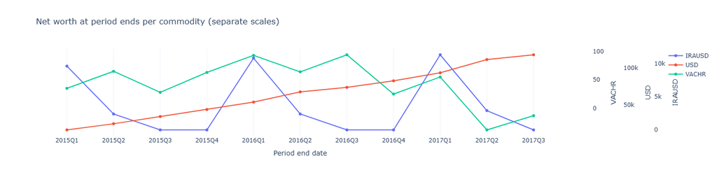

```
'USD'
```

## Financial overview

Financial overview combines information about the changes of the **Total Net Worth** over time as well as the factors, which caused these changes. I am not sure there is a formal name to this report in the world of the professional finance, but I find such report very informative for the purposes of understanding personal finance.

It is inspired by the report of the [Gainstrack](https://www.reddit.com/r/plaintextaccounting/comments/19c1xv7/)

To be able to explain the change in the **Net Worth** between any 2 periods we in general case need to know information about unrealized gains, which are not explicitly available in the beancount ledger. To derive this information we need to convert original entries to the equivalent singe currency entries by using the **get_equiv_sing_curr_entries** function from the [evbeantools.sing_curr_conv](https://github.com/Ev2geny/evbeantools/blob/main/docs/sing_curr_conv.md) package. The equivalent single currency entries will include unrealized gains transactions for every price change. The unrealyzed gains are by default collected in the accounts with the naming convention **Income:Unrealized-Gains:BBB-AAA**, where **BBB** is the target / oparational currency and the **AAA** is the currency, which price change in relation to the currency BBB has caused an unrealized gain.

|  | 2015Q1 | 2015Q2 | 2015Q3 | 2015Q4 | 2016Q1 | 2016Q2 | 2016Q3 | 2016Q4 | 2017Q1 | 2017Q2 | 2017Q3 |
| --- | --- | --- | --- | --- | --- | --- | --- | --- | --- | --- | --- |
| Expenses | 24,218.18 | 22,567.78 | 24,781.02 | 23,715.87 | 22,711.09 | 24,788.18 | 22,307.59 | 24,375.56 | 23,198.15 | 24,611.07 | 17,334.56 |
| Income | -36,677.90 | -31,438.20 | -33,694.43 | -32,570.57 | -31,475.56 | -36,227.16 | -29,702.51 | -32,569.35 | -32,172.45 | -36,779.43 | -24,637.02 |
| UnrealGains | 165.47 | 542.52 | -822.58 | -780.08 | -1,304.18 | -2,413.56 | 1,338.72 | -795.62 | -1,854.50 | -5,716.71 | 817.08 |
| Equity | -3,490.52 | 0.00 | 0.00 | 0.00 | 0.00 | 0.00 | 0.00 | 0.00 | 0.00 | 0.00 | 0.00 |
| Total Net Worth Change | -15,784.77 | -8,327.90 | -9,735.99 | -9,634.78 | -10,068.65 | -13,852.54 | -6,056.20 | -8,989.41 | -10,828.80 | -17,885.07 | -6,485.38 |
| Assets | 16,138.44 | 24,419.36 | 34,492.25 | 44,462.21 | 54,234.92 | 68,583.55 | 74,760.50 | 84,219.11 | 95,086.18 | 113,451.90 | 120,352.78 |
| Liabilities | -353.66 | -306.68 | -643.54 | -978.70 | -682.77 | -1,178.89 | -1,299.66 | -1,768.88 | -1,807.13 | -2,287.79 | -2,703.29 |
| Total Net Worth | 15,784.78 | 24,112.68 | 33,848.71 | 43,483.51 | 53,552.15 | 67,404.66 | 73,460.84 | 82,450.23 | 93,279.05 | 111,164.11 | 117,649.49 |
| Unexplained difference | nan | -0.00 | 0.03 | 0.02 | -0.00 | -0.03 | -0.02 | -0.02 | 0.03 | -0.01 | -0.00 |

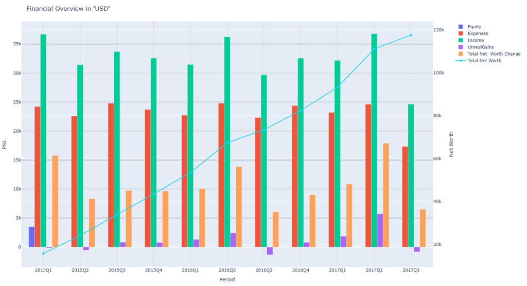

## Exploring expenses

```
start_date_iso_str: 1792-01-01
end_date_iso_str: 2017-09-30
```

| acc_L1 | acc_L2 | acc_L3 | acc_L4 | period acc_L5 | amount (USD) 2015Q1 | amount (USD) 2015Q2 | amount (USD) 2015Q3 | amount (USD) 2015Q4 | amount (USD) 2016Q1 | amount (USD) 2016Q2 | amount (USD) 2016Q3 | amount (USD) 2016Q4 | amount (USD) 2017Q1 | amount (USD) 2017Q2 | amount (USD) 2017Q3 |
| --- | --- | --- | --- | --- | --- | --- | --- | --- | --- | --- | --- | --- | --- | --- | --- |
| Financial | Commissions | _ | _ | _ | 0.00 | 0.00 | 35.80 | 35.80 | 0.00 | 44.75 | 53.70 | 8.95 | 44.75 | 0.00 | 26.85 |
|  | Fees | _ | _ | _ | 12.00 | 12.00 | 12.00 | 12.00 | 12.00 | 12.00 | 12.00 | 12.00 | 12.00 | 12.00 | 12.00 |
| Food | Alcohol | _ | _ | _ | 0.00 | 0.00 | 0.00 | 0.00 | 0.00 | 34.89 | 0.00 | 28.69 | 0.00 | 0.00 | 0.00 |
|  | Coffee | _ | _ | _ | 0.00 | 0.00 | 21.93 | 0.00 | 0.00 | 11.17 | 0.00 | 18.79 | 0.00 | 25.09 | 0.00 |
|  | Groceries | _ | _ | _ | 471.81 | 686.54 | 528.59 | 367.06 | 532.60 | 457.50 | 667.49 | 709.73 | 527.24 | 463.50 | 524.36 |
|  | Restaurant | _ | _ | _ | 1051.42 | 1130.89 | 1267.51 | 1088.92 | 895.59 | 1417.25 | 878.06 | 1207.96 | 966.60 | 1297.95 | 881.68 |
| Health | Dental | Insurance | _ | _ | 20.30 | 17.40 | 20.30 | 20.30 | 17.40 | 20.30 | 17.40 | 20.30 | 17.40 | 20.30 | 14.50 |
|  | Life | GroupTermLife | _ | _ | 170.24 | 145.92 | 170.24 | 170.24 | 145.92 | 170.24 | 145.92 | 170.24 | 145.92 | 170.24 | 121.60 |
|  | Medical | Insurance | _ | _ | 191.66 | 164.28 | 191.66 | 191.66 | 164.28 | 191.66 | 164.28 | 191.66 | 164.28 | 191.66 | 136.90 |
|  | Vision | Insurance | _ | _ | 296.10 | 253.80 | 296.10 | 296.10 | 253.80 | 296.10 | 253.80 | 296.10 | 253.80 | 296.10 | 211.50 |
| Home | Electricity | _ | _ | _ | 195.00 | 195.00 | 195.00 | 195.00 | 195.00 | 195.00 | 195.00 | 195.00 | 195.00 | 195.00 | 130.00 |
|  | Internet | _ | _ | _ | 240.31 | 240.17 | 239.79 | 239.85 | 239.77 | 239.60 | 239.78 | 240.27 | 240.26 | 239.73 | 159.98 |
|  | Phone | _ | _ | _ | 183.94 | 208.58 | 176.70 | 195.08 | 171.38 | 192.32 | 166.96 | 210.47 | 198.01 | 194.10 | 114.19 |
|  | Rent | _ | _ | _ | 7200.00 | 7200.00 | 7200.00 | 7200.00 | 7200.00 | 7200.00 | 7200.00 | 7200.00 | 7200.00 | 7200.00 | 4800.00 |
| Taxes | Y2015 | US | CityNYC | _ | 1224.44 | 1049.52 | 1224.44 | 1224.44 | 0.00 | 0.00 | 0.00 | 0.00 | 0.00 | 0.00 | 0.00 |
|  |  |  | Federal | PreTax401k | 0.00 | 0.00 | 0.00 | 0.00 | 0.00 | 0.00 | 0.00 | 0.00 | 0.00 | 0.00 | 0.00 |
|  |  |  |  | _ | 7440.44 | 6377.52 | 7440.44 | 7440.44 | 295.23 | 0.00 | 0.00 | 0.00 | 0.00 | 0.00 | 0.00 |
|  |  |  | Medicare | _ | 746.34 | 639.72 | 746.34 | 746.34 | 0.00 | 0.00 | 0.00 | 0.00 | 0.00 | 0.00 | 0.00 |
|  |  |  | SDI | _ | 7.84 | 6.72 | 7.84 | 7.84 | 0.00 | 0.00 | 0.00 | 0.00 | 0.00 | 0.00 | 0.00 |
|  |  |  | SocSec | _ | 1970.78 | 1689.24 | 1970.78 | 1369.24 | 0.00 | 0.00 | 0.00 | 0.00 | 0.00 | 0.00 | 0.00 |
|  |  |  | State | _ | 2555.56 | 2190.48 | 2555.56 | 2555.56 | 274.92 | 0.00 | 0.00 | 0.00 | 0.00 | 0.00 | 0.00 |
|  | Y2016 | US | CityNYC | _ | 0.00 | 0.00 | 0.00 | 0.00 | 1049.52 | 1224.44 | 1049.52 | 1224.44 | 0.00 | 0.00 | 0.00 |
|  |  |  | Federal | PreTax401k | 0.00 | 0.00 | 0.00 | 0.00 | 0.00 | 0.00 | 0.00 | 0.00 | 0.00 | 0.00 | 0.00 |
|  |  |  |  | _ | 0.00 | 0.00 | 0.00 | 0.00 | 6377.52 | 7440.44 | 6377.52 | 7440.44 | 463.16 | 0.00 | 0.00 |
|  |  |  | Medicare | _ | 0.00 | 0.00 | 0.00 | 0.00 | 639.72 | 746.34 | 639.72 | 746.34 | 0.00 | 0.00 | 0.00 |
|  |  |  | SDI | _ | 0.00 | 0.00 | 0.00 | 0.00 | 6.72 | 7.84 | 6.72 | 7.84 | 0.00 | 0.00 | 0.00 |
|  |  |  | SocSec | _ | 0.00 | 0.00 | 0.00 | 0.00 | 1689.24 | 1970.78 | 1689.24 | 1650.78 | 0.00 | 0.00 | 0.00 |
|  |  |  | State | _ | 0.00 | 0.00 | 0.00 | 0.00 | 2190.48 | 2555.56 | 2190.48 | 2555.56 | 456.53 | 0.00 | 0.00 |
|  | Y2017 | US | CityNYC | _ | 0.00 | 0.00 | 0.00 | 0.00 | 0.00 | 0.00 | 0.00 | 0.00 | 1049.52 | 1224.44 | 874.60 |
|  |  |  | Federal | PreTax401k | 0.00 | 0.00 | 0.00 | 0.00 | 0.00 | 0.00 | 0.00 | 0.00 | 0.00 | 0.00 | 0.00 |
|  |  |  |  | _ | 0.00 | 0.00 | 0.00 | 0.00 | 0.00 | 0.00 | 0.00 | 0.00 | 6377.52 | 7440.44 | 5314.60 |
|  |  |  | Medicare | _ | 0.00 | 0.00 | 0.00 | 0.00 | 0.00 | 0.00 | 0.00 | 0.00 | 639.72 | 746.34 | 533.10 |
|  |  |  | SDI | _ | 0.00 | 0.00 | 0.00 | 0.00 | 0.00 | 0.00 | 0.00 | 0.00 | 6.72 | 7.84 | 5.60 |
|  |  |  | SocSec | _ | 0.00 | 0.00 | 0.00 | 0.00 | 0.00 | 0.00 | 0.00 | 0.00 | 1689.24 | 1970.78 | 1407.70 |
|  |  |  | State | _ | 0.00 | 0.00 | 0.00 | 0.00 | 0.00 | 0.00 | 0.00 | 0.00 | 2190.48 | 2555.56 | 1825.40 |
| Transport | Tram | _ | _ | _ | 240.00 | 360.00 | 480.00 | 360.00 | 360.00 | 360.00 | 360.00 | 240.00 | 360.00 | 360.00 | 240.00 |
| Vacation | _ | _ | _ | _ | 0.00 | 0.00 | 0.00 | 0.00 | 0.00 | 0.00 | 0.00 | 0.00 | 0.00 | 0.00 | 0.00 |

```
start_date_iso_str: 1792-01-01
end_date_iso_str: 2017-09-30
```

| period acc_L1 | amount (USD) 2015Q1 | amount (USD) 2015Q2 | amount (USD) 2015Q3 | amount (USD) 2015Q4 | amount (USD) 2016Q1 | amount (USD) 2016Q2 | amount (USD) 2016Q3 | amount (USD) 2016Q4 | amount (USD) 2017Q1 | amount (USD) 2017Q2 | amount (USD) 2017Q3 |
| --- | --- | --- | --- | --- | --- | --- | --- | --- | --- | --- | --- |
| Financial | 12.00 | 12.00 | 47.80 | 47.80 | 12.00 | 56.75 | 65.70 | 20.95 | 56.75 | 12.00 | 38.85 |
| Food | 1523.23 | 1817.43 | 1818.03 | 1455.98 | 1428.19 | 1920.81 | 1545.55 | 1965.17 | 1493.84 | 1786.54 | 1406.04 |
| Health | 678.30 | 581.40 | 678.30 | 678.30 | 581.40 | 678.30 | 581.40 | 678.30 | 581.40 | 678.30 | 484.50 |
| Home | 7819.25 | 7843.75 | 7811.49 | 7829.93 | 7806.15 | 7826.92 | 7801.74 | 7845.74 | 7833.27 | 7828.83 | 5204.17 |
| Taxes | 13945.40 | 11953.20 | 13945.40 | 13343.86 | 12523.35 | 13945.40 | 11953.20 | 13625.40 | 12872.89 | 13945.40 | 9961.00 |
| Transport | 240.00 | 360.00 | 480.00 | 360.00 | 360.00 | 360.00 | 360.00 | 240.00 | 360.00 | 360.00 | 240.00 |
| Vacation | 0.00 | 0.00 | 0.00 | 0.00 | 0.00 | 0.00 | 0.00 | 0.00 | 0.00 | 0.00 | 0.00 |

| period acc_L1 | amount (USD) 2015Q1 | amount (USD) 2015Q2 | amount (USD) 2015Q3 | amount (USD) 2015Q4 | amount (USD) 2016Q1 | amount (USD) 2016Q2 | amount (USD) 2016Q3 | amount (USD) 2016Q4 | amount (USD) 2017Q1 | amount (USD) 2017Q2 | amount (USD) 2017Q3 |
| --- | --- | --- | --- | --- | --- | --- | --- | --- | --- | --- | --- |
| Taxes | 13945.40 | 11953.20 | 13945.40 | 13343.86 | 12523.35 | 13945.40 | 11953.20 | 13625.40 | 12872.89 | 13945.40 | 9961.00 |
| Home | 7819.25 | 7843.75 | 7811.49 | 7829.93 | 7806.15 | 7826.92 | 7801.74 | 7845.74 | 7833.27 | 7828.83 | 5204.17 |
| Food | 1523.23 | 1817.43 | 1818.03 | 1455.98 | 1428.19 | 1920.81 | 1545.55 | 1965.17 | 1493.84 | 1786.54 | 1406.04 |
| Health | 678.30 | 581.40 | 678.30 | 678.30 | 581.40 | 678.30 | 581.40 | 678.30 | 581.40 | 678.30 | 484.50 |
| Transport | 240.00 | 360.00 | 480.00 | 360.00 | 360.00 | 360.00 | 360.00 | 240.00 | 360.00 | 360.00 | 240.00 |
| Financial | 12.00 | 12.00 | 47.80 | 47.80 | 12.00 | 56.75 | 65.70 | 20.95 | 56.75 | 12.00 | 38.85 |
| Vacation | 0.00 | 0.00 | 0.00 | 0.00 | 0.00 | 0.00 | 0.00 | 0.00 | 0.00 | 0.00 | 0.00 |

| period | 2015Q1 | 2015Q2 | 2015Q3 | 2015Q4 | 2016Q1 | 2016Q2 | 2016Q3 | 2016Q4 | 2017Q1 | 2017Q2 | 2017Q3 |
| --- | --- | --- | --- | --- | --- | --- | --- | --- | --- | --- | --- |
| Taxes | 13945.40 | 11953.20 | 13945.40 | 13343.86 | 12523.35 | 13945.40 | 11953.20 | 13625.40 | 12872.89 | 13945.40 | 9961.00 |
| Home | 7819.25 | 7843.75 | 7811.49 | 7829.93 | 7806.15 | 7826.92 | 7801.74 | 7845.74 | 7833.27 | 7828.83 | 5204.17 |
| Food | 1523.23 | 1817.43 | 1818.03 | 1455.98 | 1428.19 | 1920.81 | 1545.55 | 1965.17 | 1493.84 | 1786.54 | 1406.04 |
| Health | 678.30 | 581.40 | 678.30 | 678.30 | 581.40 | 678.30 | 581.40 | 678.30 | 581.40 | 678.30 | 484.50 |
| Transport | 240.00 | 360.00 | 480.00 | 360.00 | 360.00 | 360.00 | 360.00 | 240.00 | 360.00 | 360.00 | 240.00 |
| Financial | 12.00 | 12.00 | 47.80 | 47.80 | 12.00 | 56.75 | 65.70 | 20.95 | 56.75 | 12.00 | 38.85 |
| Vacation | 0.00 | 0.00 | 0.00 | 0.00 | 0.00 | 0.00 | 0.00 | 0.00 | 0.00 | 0.00 | 0.00 |
| Total | 24218.18 | 22567.78 | 24781.02 | 23715.87 | 22711.09 | 24788.18 | 22307.59 | 24375.56 | 23198.15 | 24611.07 | 17334.56 |

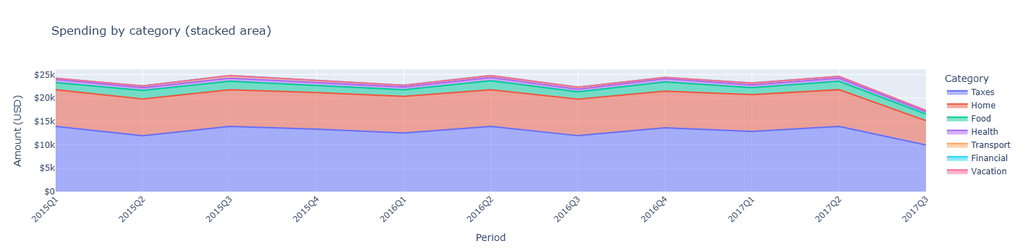

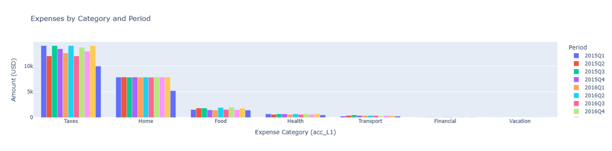

```
start_date_iso_str: 1792-01-01
end_date_iso_str: 2017-09-30
```

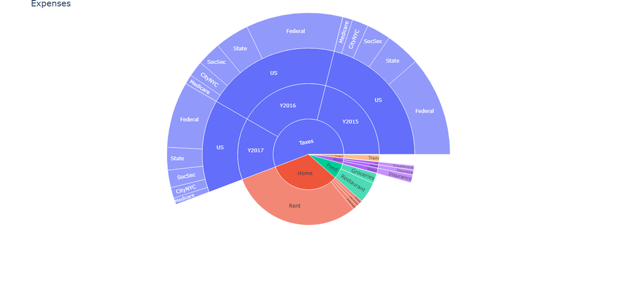

## Filtering spesific transactions

This section is reserved to be able to filter specific transactions, based on whatever criteria one needs

```
2015-01-01 open Income:US:ETrade:Gains                          USD

2015-11-18 * "Sell shares of GLD"
  Assets:US:ETrade:GLD                 -5 GLD {197.06 USD, 2015-09-15} @ 209.00 USD
  Assets:US:ETrade:Cash           1036.05 USD
  Expenses:Financial:Commissions     8.95 USD
  Income:US:ETrade:Gains           -59.70 USD

2016-04-29 * "Sell shares of VHT"
  Assets:US:ETrade:VHT                -18 VHT {112.21 USD, 2015-11-13} @ 118.03 USD
  Assets:US:ETrade:Cash           2115.59 USD
  Expenses:Financial:Commissions     8.95 USD
  Income:US:ETrade:Gains          -104.76 USD

2016-07-25 * "Sell shares of VHT"
  Assets:US:ETrade:VHT                -4 VHT {118.03 USD, 2016-05-05} @ 118.19 USD
  Assets:US:ETrade:Cash           463.81 USD
  Expenses:Financial:Commissions    8.95 USD
  Income:US:ETrade:Gains           -0.64 USD

2017-02-15 * "Sell shares of GLD"
  Assets:US:ETrade:GLD                -10 GLD {209.00 USD, 2015-11-13} @ 273.28 USD
  Assets:US:ETrade:Cash           2723.85 USD
  Expenses:Financial:Commissions     8.95 USD
  Income:US:ETrade:Gains          -642.80 USD

2017-08-22 * "Sell shares of VEA"
  Assets:US:ETrade:VEA                -4 VEA {148.59 USD, 2017-03-19} @ 145.72 USD
  Assets:US:ETrade:Cash           573.93 USD
  Expenses:Financial:Commissions    8.95 USD
  Income:US:ETrade:Gains           11.48 USD
```